# Part II - Investigating the Relationships between Variables in the Prosper Loan Data

## by Zadock Mainda

## Investigation Overview

#### Key Insights

Most of the borrowers in this dataset have a C level credit rating. This is crucial information to assist stakeholder's pinpoint the credit garde of the most borrowers and perhaps commission further exploration into their loan repayment rates.

The highest number of loans were taken in Jan while the least number of loans was listed in April. Understanding borrowing patterns throghout the year can assist the credit facility prepare incentives in advance to attracts borrowers in low seasons.

There is a weak but positive relationship between the DebtToIncomeRatio and BorrowerRate variables. As the BorrowerRate increases, DebtToIncomeRatio tends to increase also.

### Dataset Overview

The Prosper Loan Data contains a wide range of information that not only describes the borrowers' General details and loan specifics but also Estimated Loan yield among many others. These details are spread over 81 separate columns for the 113,937 loans taken at the credit facility between Nov 2005 and Mar 2014. Even though most of these variables apply to all loans between 2005 and 2014, there are some that applicable to certain period only. For instance, The prosperScore and ProsperRating are assigned to loan listings that were created after July 2009.

### How are credit ratings distributed through the dataset?

Most of the borrowers in this dataset have a C level credit rating. This is crucial information to assist stakeholder's pinpoint the credit garde of the most borrowers and perhaps commission further exploration into their loan repayment rates.

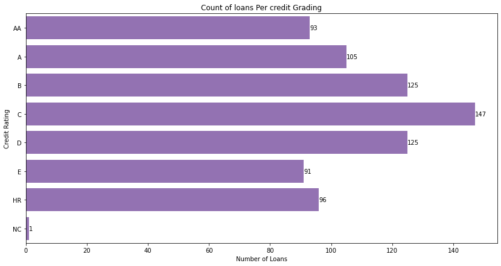

### Which is the most common Month for borrowers to take loans?

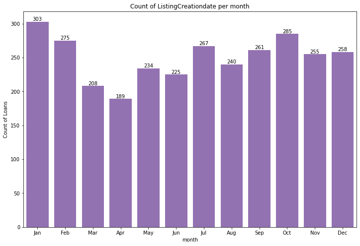

### What's the relationship between DebtToIncomeRatio and BorrowerRate variables?

There is a weak but positive relationship between the DebtToIncomeRatio and BorrowerRate variables. As the BorrowerRate increases, DebtToIncomeRatio tends to increase also.

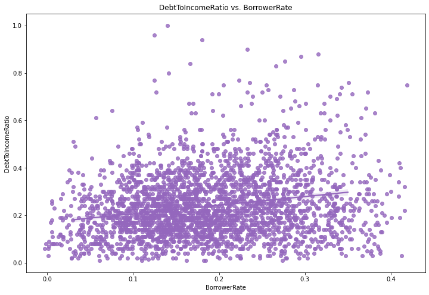